# clustering

octopus

April 4, 2017

```r
library(DESeq2)
library(ggplot2)
library(pheatmap)
library(amap)
library(dbscan)
options(width=120)
```

Чаще всего при работе с данными экспрессии используется две кластеризации: иерархическая кластеризация в пространстве образцов и K-means в пространстве генов.

В обоих случаях, мы будем использовать корреляцию (между образцами и между генами) как меру похожести для нашей кластеризации. И соотвественно 1 - cor(x, y) – как меру “непохожести”.

Также в обоих случаях, мы сначала оставим только 8000 самых сильно эспрессированных генов. Это делается за тем, что мало экспрессированные гены привносят шум в “паттерны” экспрессии, а так же невольно завышают корреляцию между образцами: ведь они слабо экспрессированы во всех образцах.

## Задание 1: иерархическая кластеризация (для обнаружения аутлаера)

Возьмем весь датасет с аутлаером Создадим DeseqDataSet объект (дизайн не важен) Оставим только 8000 экспрессированых генов

```r
counts <- read.csv("GSE89225_Illumina_counts.csv", row.names=1)
conditions <- read.csv("conditions.csv", row.names=1)
mart <- read.table("human_mart.txt", sep="\t", header=1, check.names = F)

dds <- DESeqDataSetFromMatrix(countData = counts,
                              colData = conditions,
                              design = ~ tissue + cells)

dds_high_expr <- dds[order(rowSums(counts(dds)), decreasing = TRUE), ][1:8000, ]
dds_high_expr <- DESeq(dds_high_expr)
```

Используем rlog(dds) для получения логарифмированных значений экспрессии Посчитаем корреляции между образцами используя cor (результатом будет матрица размера m×m, где m – количество образцов)

```r
dds_high_expr_log_cor <- cor(assay(rlog(dds_high_expr)))
dds_high_expr_log_cor[1:2, ]
```

```
##                              tconv_tumor_patient10 cd177negtreg_tumor_patient10 cd177postreg_tumor_patient10
## tconv_tumor_patient10                    1.0000000                    0.9422145                    0.9103666
## cd177negtreg_tumor_patient10             0.9422145                    1.0000000                    0.9393511
##                              tconv_tumor_patient1 treg_tumor_patient1 tconv_NBP_patient2 treg_NBP_patient2
## tconv_tumor_patient10                   0.8911076           0.8441285          0.9361642         0.8652160
## cd177negtreg_tumor_patient10            0.8517361           0.8527350          0.8796454         0.8781851
##                              tconv_tumor_patient2 cd177negtreg_tumor_patient2 cd177postreg_tumor_patient2
## tconv_tumor_patient10                   0.9446824                   0.8934366                   0.8664625
## cd177negtreg_tumor_patient10            0.9174500                   0.9247041                   0.9018151
##                              tconv_NBP_patient3 treg_NBP_patient3 tconv_tumor_patient3 cd177negtreg_tumor_patient3
## tconv_tumor_patient10                 0.9388213         0.7397509            0.9157097                   0.8884843
## cd177negtreg_tumor_patient10          0.8927638         0.7526884            0.8734194                   0.8982310
##                              cd177postreg_tumor_patient3 tconv_NBP_patient4 treg_NBP_patient4 tconv_tumor_patient4
## tconv_tumor_patient10                          0.8273788          0.9431131         0.9035287            0.9484299
## cd177negtreg_tumor_patient10                   0.8619950          0.8803706         0.9142820            0.8907121
##                              cd177negtreg_tumor_patient4 cd177postreg_tumor_patient4 treg_tumor_patient5
## tconv_tumor_patient10                          0.8779402                   0.8391912           0.8684060
## cd177negtreg_tumor_patient10                   0.8916376                   0.8860247           0.8636783
##                              tconv_tumor_patient5 tconv_tumor_patient6 cd177negtreg_tumor_patient6
## tconv_tumor_patient10                   0.9189726            0.9467226                   0.8728600
## cd177negtreg_tumor_patient10            0.8624920            0.9170546                   0.8747886
##                              cd177postreg_tumor_patient6 tconv_NBP_patient7 treg_NBP_patient7 tconv_NBP_patient8
## tconv_tumor_patient10                          0.8595701          0.9311323         0.9391161          0.9123021
## cd177negtreg_tumor_patient10                   0.8815004          0.8592100         0.9112982          0.8925387
##                              treg_NBP_patient8 treg_tumor_patient8 tconv_tumor_patient8 tconv_NBP_patient9
## tconv_tumor_patient10                0.8635969           0.8837695            0.9215092          0.9301827
## cd177negtreg_tumor_patient10         0.8723197           0.8968830            0.8561020          0.8612449
##                              treg_NBP_patient9 tconv_tumor_patient9
## tconv_tumor_patient10                0.9099621            0.9056211
## cd177negtreg_tumor_patient10         0.8951459            0.8597108
```

Посчитаем матрицу “непохожести” 1 - cor, и dist объект для этой матрицы

```r
dds_high_expr_log_revcor <- 1 - dds_high_expr_log_cor
dds_high_expr_log_revcor_dist <- dist(dds_high_expr_log_revcor)
```

Сделаем кластеризацию с помощью функции hclust, используя три разных метода “связывания” объектов в группы: average, complete and single Построим для каждой график с помощью plot

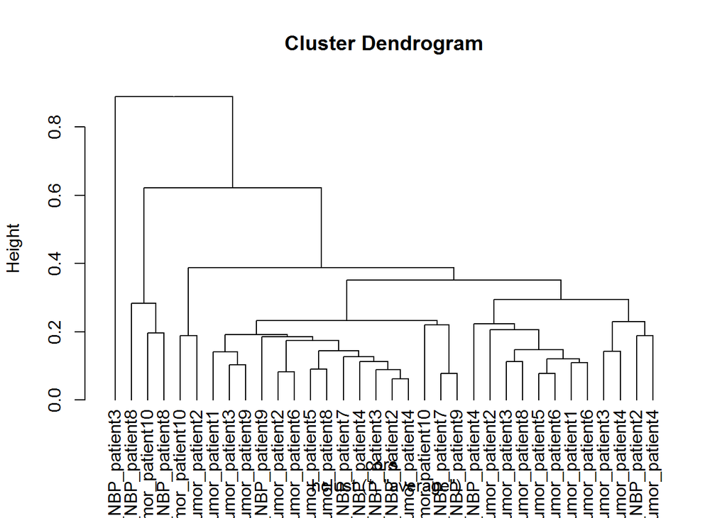

```r
average_bind <- hclust(dds_high_expr_log_revcor_dist, method="average")
complete_bind <- hclust(dds_high_expr_log_revcor_dist, method="complete")
single_bind <- hclust(dds_high_expr_log_revcor_dist, method="single")

plot(as.dendrogram(average_bind), ylab = "Height", xlab = "cors \n hclust (*, \"average\")", main = "Cluster Dendrogram")
```

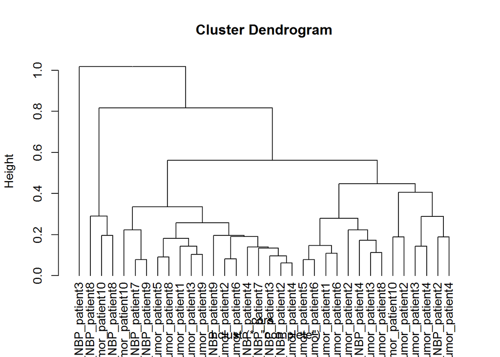

```r
plot(as.dendrogram(complete_bind), ylab = "Height", xlab = "cors \n hclust (*, \"complete\")", main = "Cluster Dendrogram")
```

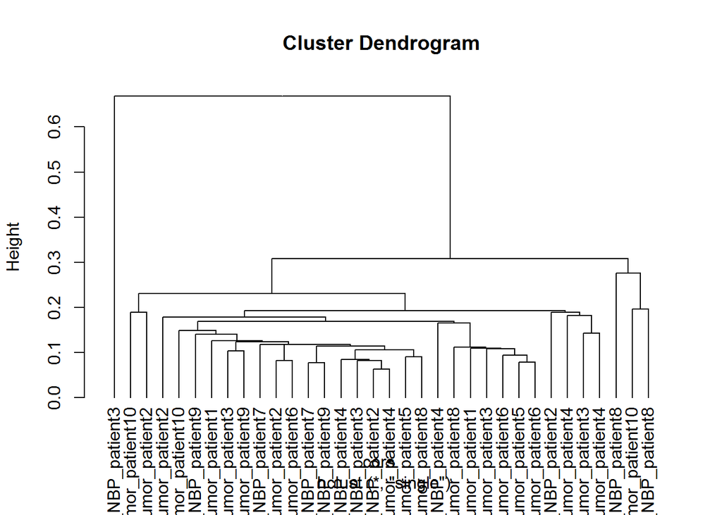

```r
plot(as.dendrogram(single_bind), ylab = "Height", xlab = "cors \n hclust (*, \"single\")", main = "Cluster Dendrogram")
```

## Задание 2: K-means для описания паттернов экспрессии

Возьмем весь датасет без аутлаера Создадим DeseqDataSet объект (дизайн не важен) Оставим только 8000 экспрессированных генов

```r
counts$treg_NBP_patient3 <- NULL
conditions <- conditions[rownames(conditions) != "treg_NBP_patient3",  ]

dds <- DESeqDataSetFromMatrix(countData = counts,
                              colData = conditions,
                              design = ~ tissue + cells)

dds_high_expr <- dds[order(rowSums(counts(dds)), decreasing = TRUE), ][1:8000, ]
dds_high_expr <- DESeq(dds_high_expr)
```

Используем rlog(dds) для получения логарифмированных значений экспрессии

```r
dds_high_expr_log <- assay(rlog(dds_high_expr))
dds_high_expr_log[1:2, ]
```

```
##                 tconv_tumor_patient10 cd177negtreg_tumor_patient10 cd177postreg_tumor_patient10 tconv_tumor_patient1
## ENSG00000166710              18.38981                     18.31011                     17.31123             19.14593
## ENSG00000210082              18.38451                     18.78427                     18.72291             17.76873
##                 treg_tumor_patient1 tconv_NBP_patient2 treg_NBP_patient2 tconv_tumor_patient2
## ENSG00000166710            19.08837           18.69114          18.65373             18.43818
## ENSG00000210082            17.21380           18.34532          18.12507             18.56321
##                 cd177negtreg_tumor_patient2 cd177postreg_tumor_patient2 tconv_NBP_patient3 tconv_tumor_patient3
## ENSG00000166710                    18.20358                    18.70467           18.76245             18.86842
## ENSG00000210082                    18.58593                    18.21441           18.13456             18.83624
##                 cd177negtreg_tumor_patient3 cd177postreg_tumor_patient3 tconv_NBP_patient4 treg_NBP_patient4
## ENSG00000166710                    18.68579                    19.16978           18.66278          18.92703
## ENSG00000210082                    18.23185                    18.18326           18.64441          18.31996
##                 tconv_tumor_patient4 cd177negtreg_tumor_patient4 cd177postreg_tumor_patient4 treg_tumor_patient5
## ENSG00000166710             18.49006                    19.43061                    19.14506            18.74935
## ENSG00000210082             18.51856                    18.68896                    18.41583            17.31384
##                 tconv_tumor_patient5 tconv_tumor_patient6 cd177negtreg_tumor_patient6 cd177postreg_tumor_patient6
## ENSG00000166710             18.79429             18.64249                    18.67532                    18.86959
## ENSG00000210082             18.13462             18.65340                    18.24833                    18.04818
##                 tconv_NBP_patient7 treg_NBP_patient7 tconv_NBP_patient8 treg_NBP_patient8 treg_tumor_patient8
## ENSG00000166710           18.03774          18.26001           17.80759          17.12765            18.38976
## ENSG00000210082           17.76528          17.63118           18.05979          18.58185            16.99675
##                 tconv_tumor_patient8 tconv_NBP_patient9 treg_NBP_patient9 tconv_tumor_patient9
## ENSG00000166710             18.40629           18.22601          18.13726             18.87471
## ENSG00000210082             17.66640           17.70947          17.16904             17.88512
```

Используем функцию Kmeans из пакета amap с методом “correlation”, c количеством кластеров равным 6. (Вы можете выбрать своё количество кластеров), и максимальным количеством итераций равным 20000 После этого вы можете достать соотвествие каждого гена кластеру с помощью элемента листа с названием “cluster”

```r
clustering <- Kmeans(dds_high_expr_log, 6, method="correlation", iter.max=20000)
head(clustering$cluster)
```

```
## ENSG00000166710 ENSG00000210082 ENSG00000251562 ENSG00000075624 ENSG00000198804 ENSG00000198938
##               2               6               3               2               1               1
```

После этого от вас потребуется эту кластеризацию изобразить на хитмапе: гены должны быть отсортированы по кластерам, а столбцы сначала по клеткам, а затем по тканям.

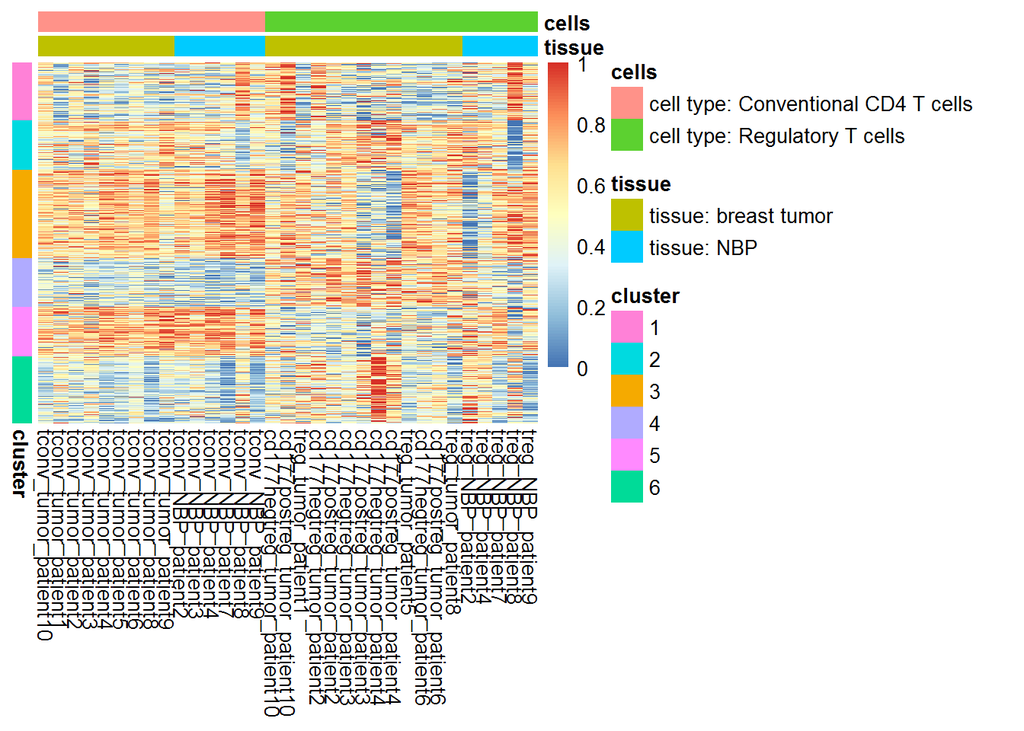

```r
to_visualise <- dds_high_expr_log[order(clustering$cluster), order(conditions[, 2], conditions[, 1])]
to_visualise <- t(apply(to_visualise, 1, function(r) {
  (r - min(r)) / (max(r) - min(r))
}))

pheatmap(to_visualise,
         show_rownames = F, cluster_rows = F,
         cluster_cols=F,
         annotation_col = conditions,
         annotation_row = data.frame(cluster = as.factor(clustering$cluster)))
```

```r
# dev.off()
```

## Задание 3: Density based algortihms (DBSCAN) для нахождения “плотных” кластеров без априорного знания их числа

### *но аргументы ϵ и k мы всё же сами подбираем

В архиве находится файлик projection.csv, который содержит в себе результаты анализа данных single-cell RNA-seq, а именно tSNE-проекции всех клеток. По сути каждая клетка здесь определена в двумерном пространстве, и клетки, транскрипционные профили которых бризки друг к другу, находятся на этой проекции близко, а те, что транскрипционно различаются, – находятся дальше.

Базовая концепция алгоритма DBSCAN очень простая – для каждой точки, мы можем посмотреть количество точек-соседей, которые находятся к ней ближе какого-то расстояния ϵ. Если количество точек в этой ϵ-окрестности больше или равно заранее определенному числу k, и какие-то из этих точек-соседей уже лежат в кластере – то нашу точку можно в этот кластер добавить.

Пакет dbscan доступен из CRAN, функция dbscan принимает, кроме объекта с точками в пространстве, два аргумента: радиус окружности вокруг точки ϵ, в которой мы пытаемся найти достаточноe число соседей, и достаточно число соседей k в этой окружности.

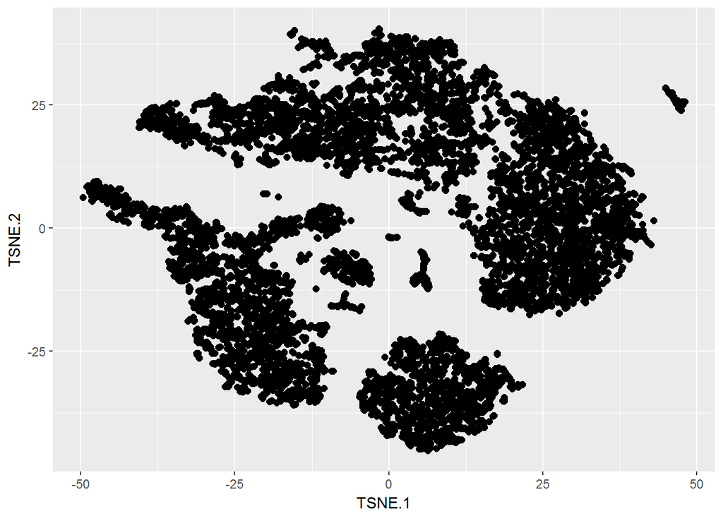

```r
projection <- read.csv("projection.csv")
projection <- projection[ , 2:3]
projection_dbscan <- dbscan(projection, eps = 4, minPts = 7)
cluster <- as.factor(projection_dbscan$cluster)

ggplot(projection, aes(x = TSNE.1, y = TSNE.2)) +
  geom_point(size = 2)  +
  xlab("TSNE.1") +
  ylab("TSNE.2")
```

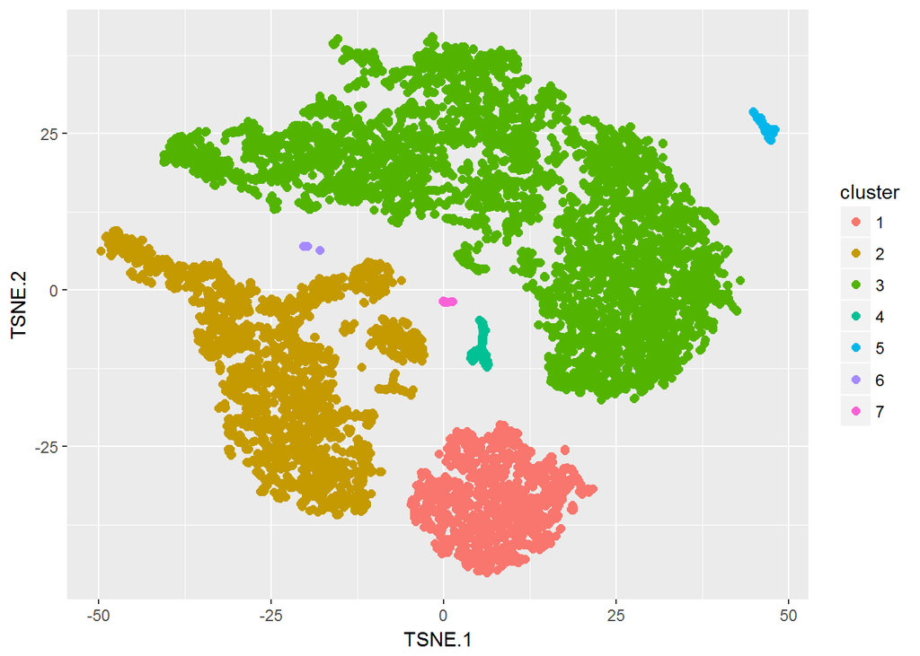

```r
ggplot(projection, aes(x = TSNE.1, y = TSNE.2, col = cluster)) +
  geom_point(size = 2) +
  xlab("TSNE.1") +
  ylab("TSNE.2")
```